# Lesson 3: Clustering, annotation and functional analysis

```r
library(Seurat)
library(dplyr)
```

Last week, we carried out pre-processing steps. These included:

- Quality control of low-quality cells or doublets
- Finding the most important features
- Dimensionality reduction with PCA

We saved everything in a Seurat object. If you don’t have your object saved (containing the PBMC data pre-processed and PCA performed), then don’t worry! Load up the pbmc_preprocessed.RDS file like so:

```r
pbmc = readRDS("pbmc_preprocessed.RDS")
```

To remind you, here is the Elbow plot we plotted to try and figure out the dimensionality of the dataset.

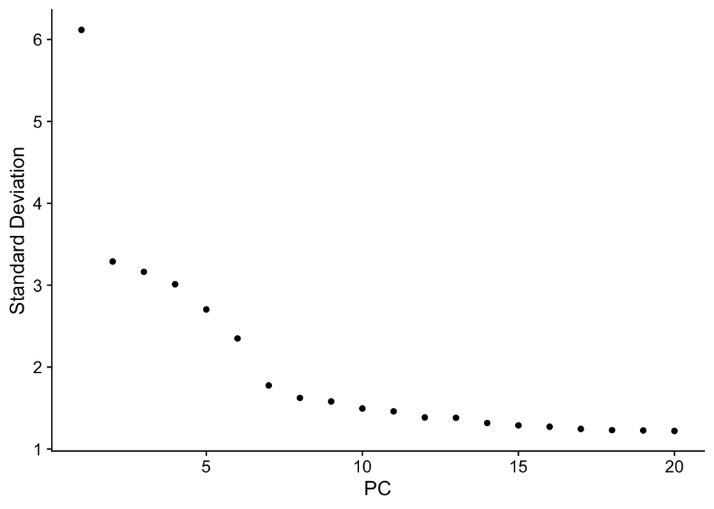

```r
ElbowPlot(pbmc)
```

We are going to take the first 10 PCs forward to the next stage.

## Cluster the cells

As the purpose of most single cell RNA-seq experiments will be to find some heterogeneity of cells within a sample, we will be attempting to cluster the cells into distinct communities. This is carried out using a graph-based clustering approach. This method embeds cells in a network structure (for example, a K-nearest neighbour network), with edges drawn between cells with similar feature expression patterns. The graph is then partitioned into highly interconnected communities. The fine mathematical details of this are beyond the scope of this session, but below we summarise the steps. If you want to read more about it then feel free, but you shouldn’t need to know it in too much detail to be able to carry out the analysis; only have a general sense of what’s happening.

The KNN network is constructed based on the euclidean distance in PCA space, and edge weights are refined between two cells based on the shared overlap in their local neighbourhoods. This step is performed using the `FindNeighbors` function, which takes as input the previously defined dimensionality of the dataset (first 10 PCs).

We then apply a modularity optimisation technique called the Louvain algorithm to iteratively group cells together. The value to be optimised is the “modularity”, which measures the density of links inside communities compared to links between communities. This is represented by the `FindClusters` function, which also takes as input a “resolution” parameter. This just sets the “granularity” of the downstream clustering, with increased values leading to a greater number of clusters. The typical value for this is usually between 0.4 - 1.2 for a set of around 3K cells.

We use a graph-based clustering algorithm because it means we only need to calculate distances once (in the FindNeighbours step), and then the clustering (FindClusters) calculations are much faster.

```r
pbmc <- FindNeighbors(pbmc, dims=1:10)
pbmc <- FindClusters(pbmc, resolution=0.4) # you can set this as default, then carry out the next steps and decide if you need to change resolution
```

```
## Modularity Optimizer version 1.3.0 by Ludo Waltman and Nees Jan van Eck
##
## Number of nodes: 2638
## Number of edges: 90257
##
## Running Louvain algorithm...
## Maximum modularity in 10 random starts: 0.8997
## Number of communities: 9
## Elapsed time: 0 seconds
```

## Visualise the clusters

We will now be running a UMAP reduction to visualise the dataset. The goal of UMAP is to learn the underlying manifold of the data in order to place similar cells together in low-dimensional space. Cells within the graph-based clusters determined above should co-localize on these dimension reduction plots. As input to the UMAP, we use the same PCs as input to the clustering analysis.

```r
pbmc <- RunUMAP(pbmc,dims=1:10)
```

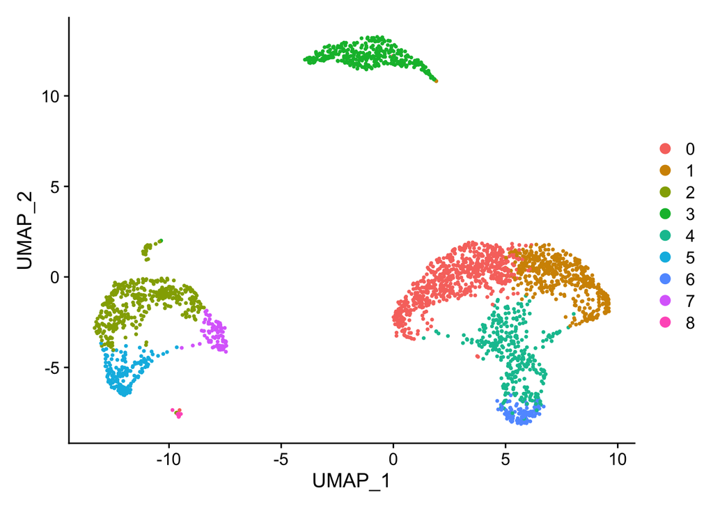

```r
DimPlot(pbmc, reduction = "umap")
```

```r
saveRDS(pbmc,file="pbmc_umap.rds")
```

## Finding differentially expressed features (cluster biomarkers)

So we’ve found 9 cell clusters, which seem to form 3 larger clusters in our low-dimensional UMAP space. But to be able to make any conclusions about our data, we need to understand what defines these clusters in terms of the genes differentially expressed between them.  
This is achieved using the `FindAllMarkers` function which tests differential expression between every combination of pairs of clusters using the Wilcoxon Rank Sum Test (a nonparametric test of the null hypothesis that it is equally likely that a randomly selected value from one population will be less than or greater than a randomly selected value from a second population, used to investigate whether two independent samples were selected from populations having the same distribution).  
The min.pct parameter requires a feature to be detected at a minimum percentage of either of the two groups of cells, and the logfc.threshold argument limits testing to genes which show, on average, at least X-fold difference (log-scale) between the two groups of cells. Increasing these two parameters speeds up the function, but can miss weaker signals. We use the default values here. We also only report the positive markers.  
The resulting table is useful to demonstrate the top 10 genes, per cluster, which characterise the cluster the best.

```r
pbmc.markers = FindAllMarkers(pbmc, only.pos=TRUE,min.pct=0.25,logfc.threshold=0.25)
pbmc.markers %>% group_by(cluster) %>% top_n(n = 10, wt = avg_logFC) # show the genes
```

```
## # A tibble: 90 x 7
## # Groups:   cluster [9]
##        p_val avg_logFC pct.1 pct.2 p_val_adj cluster gene
##        <dbl>     <dbl> <dbl> <dbl>     <dbl> <fct>   <chr>
##  1 3.52e-144      44.0 1     0.991 4.83e-140 0       RPS12
##  2 2.03e- 71      92.3 1     0.999 2.79e- 67 0       MALAT1
##  3 5.16e- 68      40.3 0.325 0.066 7.08e- 64 0       MAL
##  4 1.03e- 16      43.5 0.446 0.284 1.41e- 12 0       CCDC109B
##  5 6.01e- 14      45.6 0.941 0.837 8.24e- 10 0       ACTG1
##  6 7.94e- 12      50.0 0.32  0.197 1.09e-  7 0       TERF2IP
##  7 4.91e- 11      52.0 0.351 0.224 6.73e-  7 0       RWDD1
##  8 3.25e-  8      40.3 0.297 0.199 4.45e-  4 0       NSA2
##  9 2.40e-  7      39.1 0.284 0.19  3.29e-  3 0       HAX1
## 10 5.83e-  5      51.9 0.291 0.363 8.00e-  1 0       LAMTOR1
## # … with 80 more rows
```

To visualise marker expression we can use a violin plot, showing expression probability distributions across clusters. This is useful if you have a particular marker gene you are interested in.

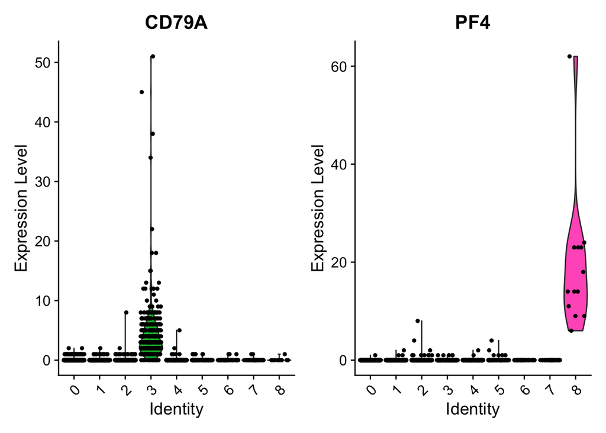

```r
VlnPlot(pbmc, features = c("CD79A", "PF4"))
```

An especially nice way to visualise and interpret the results is using the cluster biomarker values overlayed on the UMAP plots.

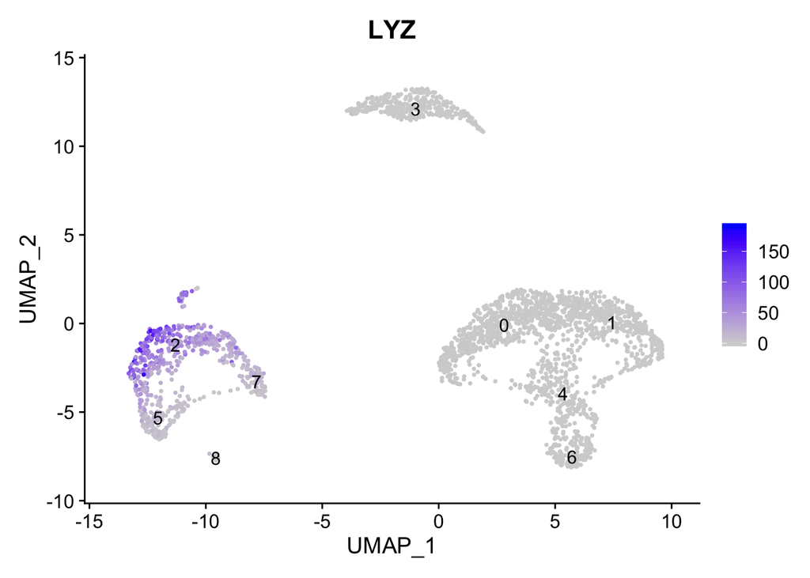

```r
FeaturePlot(pbmc, features = c("LYZ"),label = T)
```

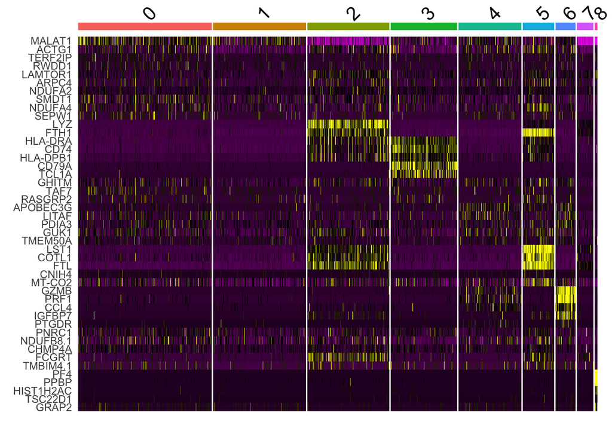

```r
top10 <- pbmc.markers %>% group_by(cluster) %>% top_n(n = 5, wt = avg_logFC)
DoHeatmap(pbmc, features = top10$gene) + NoLegend()
```

## Assigning cell types to clusters

Fortunately in the case of this dataset, canonical markers have been used previously to easily match the unbiased clustering to known cell types:

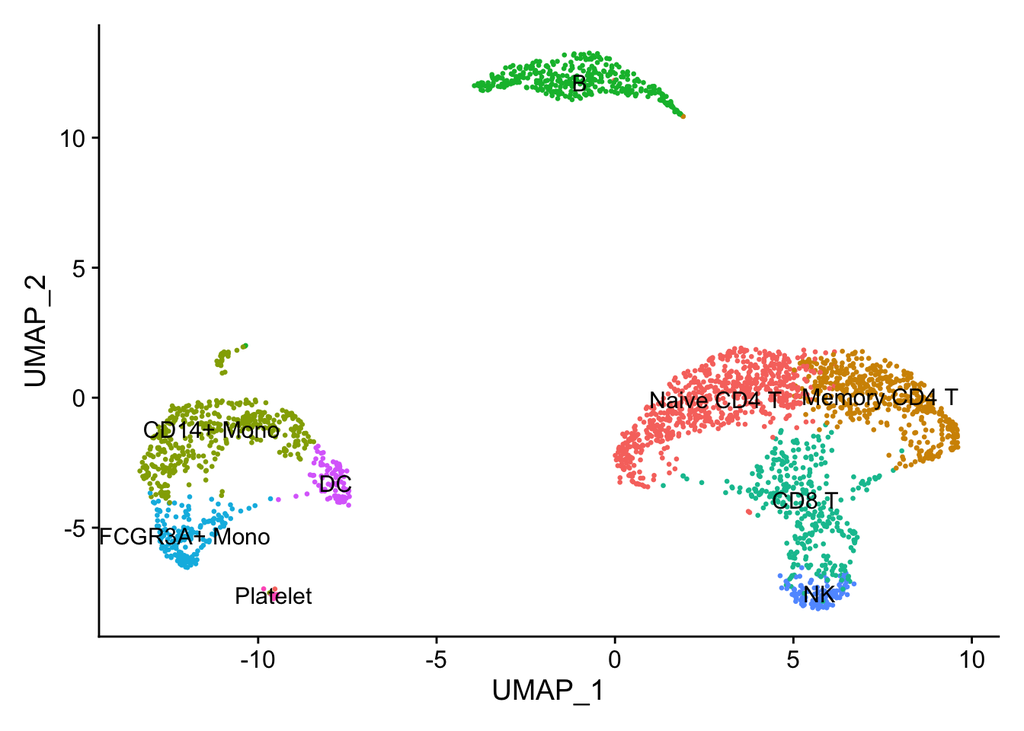

```r
new.cluster.ids <- c("Naive CD4 T", "Memory CD4 T", "CD14+ Mono", "B", "CD8 T", "FCGR3A+ Mono",
    "NK", "DC", "Platelet")
names(new.cluster.ids) <- levels(pbmc)
pbmc <- RenameIdents(pbmc, new.cluster.ids)
DimPlot(pbmc, reduction = "umap", label = TRUE, pt.size = 0.5) + NoLegend()
```

However, we might not always be able to assign cell types based on the biomarkers, for example if the separation isn’t as obvious as it is in this dataset, or if we simply want to carry out a more data-driven approach. In cases like this, we can use prior knowledge from other datasets to annotate our cells. We will use a package called SingleR to do this.

SingleR provides several reference datasets (mostly derived from bulk RNA-seq or microarray data) through dedicated data retrieval functions. For example, we obtain reference data from the Human Primary Cell Atlas using the `HumanPrimaryCellAtlasData()` function, which returns a `SummarizedExperiment` object containing matrix of log-expression values with sample-level labels.

```r
library(SingleR)
hpca.se <- HumanPrimaryCellAtlasData()
```

```
## snapshotDate(): 2019-10-22
```

```
## see ?SingleR and browseVignettes('SingleR') for documentation
```

```
## loading from cache
```

```
## see ?SingleR and browseVignettes('SingleR') for documentation
```

```
## loading from cache
```

```r
hpca.se
```

```
## class: SummarizedExperiment
## dim: 19363 713
## metadata(0):
## assays(1): logcounts
## rownames(19363): A1BG A1BG-AS1 ... ZZEF1 ZZZ3
## rowData names(0):
## colnames(713): GSM112490 GSM112491 ... GSM92233 GSM92234
## colData names(2): label.main label.fine
```

We use our hpca.se reference to annotate each cell via the `SingleR()` function. Given a reference dataset of samples with known labels (hpca.se), it labels new cells from a test dataset based on similarity to the reference set. Note that the default marker detection method is to take the genes with the largest positive log-fold changes in the per-label medians for each gene. We can then add these annotations as metadata and plot the labels on top of the UMAP.

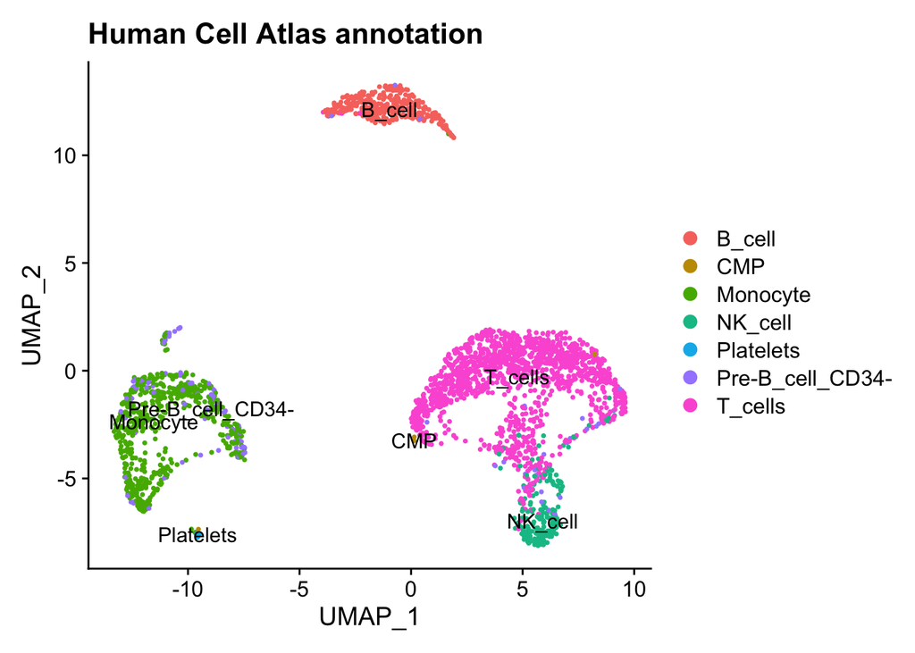

```r
library(ggplot2)
pbmc.sce <- as.SingleCellExperiment(pbmc)
pred.cells <- SingleR(test=pbmc.sce,ref=hpca.se,labels=hpca.se$label.main)
pbmc <- AddMetaData(pbmc,
                   col.name = 'pred.cells',
                   metadata = pred.cells$first.labels)
DimPlot(pbmc, reduction='umap',group.by = 'pred.cells',label=T)+labs(title="Human Cell Atlas annotation")
```

It did pretty well!

We can repeat this for different reference datasets to find a consensus.

```r
# blueprint
blueprint.se = BlueprintEncodeData()
```

```
## snapshotDate(): 2019-10-22
```

```
## see ?SingleR and browseVignettes('SingleR') for documentation
```

```
## loading from cache
```

```
## see ?SingleR and browseVignettes('SingleR') for documentation
```

```
## loading from cache
```

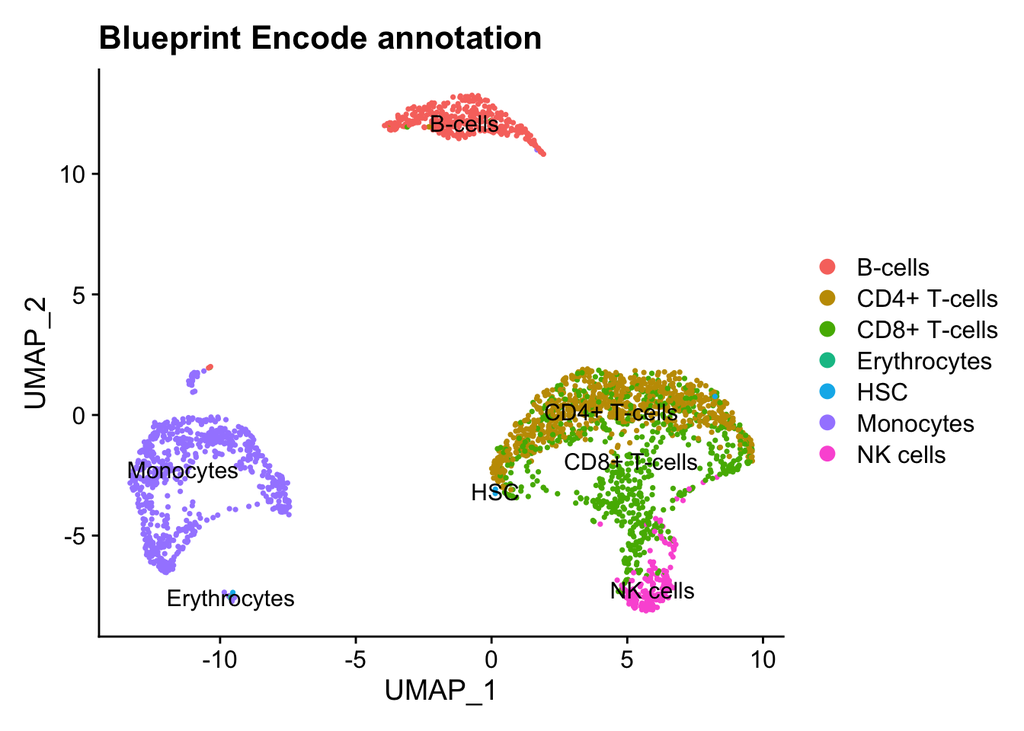

```r
blueprint.cells <- SingleR(test=pbmc.sce,ref=blueprint.se,labels=blueprint.se$label.main)
pbmc <- AddMetaData(pbmc,
                   col.name = 'blueprint.cells',
                   metadata = blueprint.cells$first.labels)
DimPlot(pbmc, reduction='umap',group.by = 'blueprint.cells',label=T)+labs(title="Blueprint Encode annotation")
```

```r
# immune cell expression data
immcell.se = DatabaseImmuneCellExpressionData()
```

```
## snapshotDate(): 2019-10-22
```

```
## see ?SingleR and browseVignettes('SingleR') for documentation
```

```
## loading from cache
```

```
## see ?SingleR and browseVignettes('SingleR') for documentation
```

```
## loading from cache
```

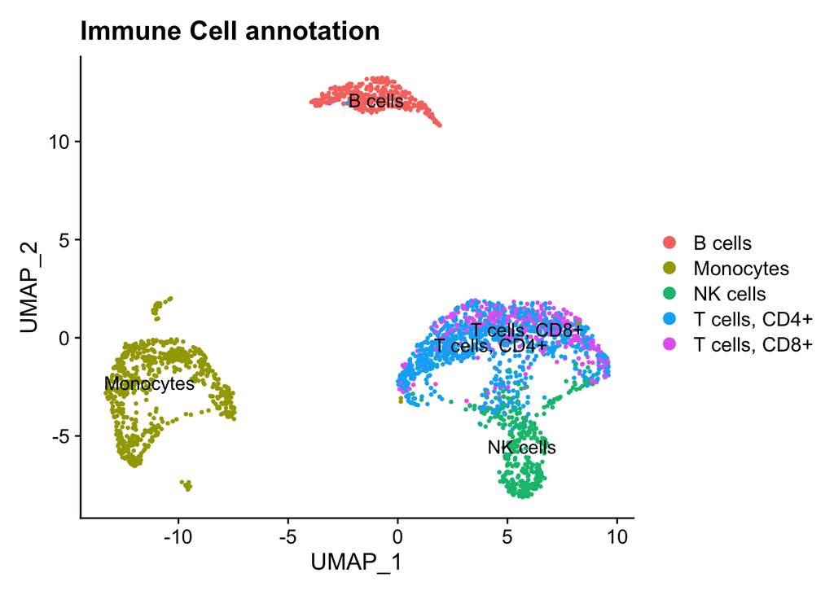

```r
immcell.cells <- SingleR(test=pbmc.sce,ref=immcell.se,labels=immcell.se$label.main)
pbmc <- AddMetaData(pbmc,
                   col.name = 'immcell.cells',
                   metadata = immcell.cells$first.labels)
DimPlot(pbmc, reduction='umap',group.by = 'immcell.cells',label=T)+labs(title="Immune Cell annotation")
```

## Functional enrichment of cell biomarkers

As well as annotating by cell type, it might be useful to understand the shared functions of the biomarker genes based on the pathways and processes they are involved in. We do this by performing “pathway enrichment” using a method called ORA. ORA takes the top differentially expressed genes and looks for their over-representation in pathway gene sets, calculating the statistical significance of this overlap. Here we will take the top 100 genes by logfc per cluster for the enrichment, and format the results ready for clusterProfiler. We use GO Biological Process as our gene set database.

```r
library(clusterProfiler)
library(org.Hs.eg.db)
library(ReactomePA)
```

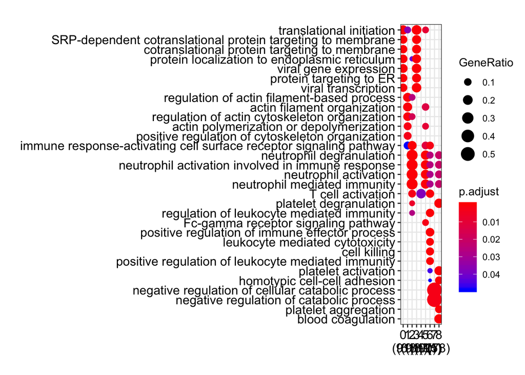

```r
top_100 = pbmc.markers %>% group_by(cluster) %>% top_n(n = 100, wt = avg_logFC)

# create named vec
gcSample = list()
for(i in seq(0,8,1)){
  cluster_markers = subset(top_100,cluster==i)
  cluster_markers = cluster_markers[order(-cluster_markers$avg_logFC),]
  cluster_markers = head(cluster_markers,n=100)$gene
  i = as.character(i)
  gcSample[[i]] <- cluster_markers
}
ck <- compareCluster(geneCluster = gcSample,fun="enrichGO",pvalueCutoff=0.05,OrgDb='org.Hs.eg.db',ont="BP",keyType="SYMBOL")
dotplot(ck)
```